# Draft-assinment1

Kun Shen, Xiang Li, Xue Zhou

February 10, 2017

# 1. Introduction

# 2. Objective

# 3. Dataset Preparation

The following libraries have been used in the analysis:

```r
library(readr)
library(dplyr)
library(ggplot2)
library(tidyr)
library(ggvis)
library(plyr)
```

We loaded ScoreCard from the US Dapartment of Education. The main dataset spans nearly 20 years of data and covering multiple sources including IPEDS, NSLDS, and Department of Treasury. To ensure the maximum data accurary and availablity, we choose the subset of year 2012 - 2013 as our analysis sample.

```r
data = read.csv("MERGED2012_13_PP.csv",header = T, na.strings = c("NULL","PrivacySuppressed"))
```

The full dataset contains 1743 variables. 36 variables were intially selected to analyze.

```r
variable = select(data, STABBR, PREDDEG, LOCALE2, MENONLY, WOMENONLY, CONTROL, ADM_RATE, SATMTMID, SATVRMID, SATWRMID, SAT_AVG,
                  NPT4_PUB,
                  NPT4_PRIV,
                  UG,
                  UG_NRA,
                  UG_UNKN,
                  UG_WHITENH,
                  UG_BLACKNH,
                  UG_API,
                  UG_AIANOLD,
                  UG_HISPOLD,
                  DEP_STAT_PCT_IND,
                  PAR_ED_PCT_1STGEN,
                  MD_FAMINC,
                  MEDIAN_HH_INC,
                  POVERTY_RATE,
                  PCTPELL,
                  PCTFLOAN,
                  GRAD_DEBT_MDN,
                  WDRAW_DEBT_MDN,
                  APPL_SCH_PCT_GE2,
                  C150_4,
                  MD_EARN_WNE_P6,
                  MD_EARN_WNE_P10,
                  RPY_3YR_RT_SUPP,
                  CDR3)
```

After loading the dataset, we change variables to the correct data types.

```r
class(as.data.frame(apply(variable[,-c(1,2,6)],2,as.numeric)))
```

```
## [1] "data.frame"
```

```r
#numeric
variable[,-c(1,2,6)] %>%
    apply(2, as.numeric) %>%
    as.data.frame() %>%
    {.} -> variable_num

#categorical
variable$preF=factor(variable$PREDDEG,levels=c(0,1,2,3,4),labels = c("NotClassified","Certificate-degree","Associate's-degree","Bachelor's-degree","Graduate-degree"))
variable$ctrF=factor(variable$CONTROL,levels = c(1,2,3),labels = c("Public","Private Nonprofit","Private For-profit"))

#combine the three datafram to generate a new dataset.
data_new <- cbind(variable_num, variable$preF, variable$ctrF,variable$STABBR)
dim(data_new)
```

```
## [1] 7793   36
```

```r
mean(is.na(data_new$NPT4_PUB))
```

```
## [1] 0.7520852
```

Considering the variable NPT4_PUB and NPT4_PRIV are mutually exclusive, to maximize the data integrity, we integrated the information of the two coloumns into a single cololumn, named with “NPT4_COMBINE”. The new coloumn records the average net price for TITLE IV institutions of both public and private.

```r
for (i in 1:length(data_new$NPT4_PRIV)) {
   if (is.na(data_new$NPT4_PRIV[i])) {
       data_new$NPT4_PRIV[i] = data_new$NPT4_PUB[i]
   }
}
mean(is.na(data_new$NPT4_PRIV))
```

```
## [1] 0.1453869
```

```r
data_new = data_new[,-9]
colnames(data_new)[9] <- "NPT4_COMBINE"
```

In order to choose the variables that have enough valid data related to the topic, we filtered and considered variables with percent missing value less than 25%. The new data set was named as “data_clean” for further analysis.

```r
data_clean = data_new[,colMeans(is.na(data_new)) < 0.25]
write.csv(data_clean,"data_clean.csv")
```

# 4. Goals

# 5. Summary of variables

For numeric variabls, we calculate the basic summary statistics such as median, min, max, mode and quantile. We also use visualizations such as hisgroms and boxplots to understand the distribution of the values. For categorical variables, we use frequency table to understand the frequcies of each categories.Box chart is used as a visualization tool.

| Variable Name | Data Type | Description | Categoriy in Documentation |
| --- | --- | --- | --- |
| NPT4_COMBINE | Numeric | average net price for TITLE IV institutions of both public and private. | Cost |
| DEP_STAT_PCT_IND | Numeric | Percentage of students who are financially independent | Cost |
| PAR_ED_PCT_1STGEN | Numeric | Percentage first-generation students | Sudent Body |
| MD_FAMINC | Numeric | Median family income in real 2015 dollars | Earning |
| PCTPELL | Numeric | Percentage of undergraduates who receive a Pell Grant | Financial Aid |
| PCTFLOAN | Numeric | Percent of all federal undergraduate students receiving a federal student loan | Financial Aid |
| GRAD_DEBT_MDN | Numeric | The median debt for students who have completed | Financial Aid |
| WDRAW_DEBT_MDN | Numeric | Continuous | n |
| MD_EARN_WNE_P6 | Numeric | Continuous | n |
| MD_EARN_WNE_P10 | Numeric | Continuous | n |
| RPY_3YR_RT_SUPP | Numeric | Continuous | n |
| CDR3 | Numeric | Continuous | n |
| variable$qreF | Factor | Categorical | n |
| variable$ctrF | Factor | Categorical | n |
| variable$STABBR | Factor | Categorical | n |
| APPL_SCH_PCT_GE2 | Numeric | Continuous | Student |

we will summarize the data set using dplyr functions in the variables summary section.

## 5.1 Individual variable summary

### 5.1.1 School

#### 5.1.1.1. State

```r
state_freq = count(data_clean,"variable$STABBR")[order(-count(data_clean,'variable$STABBR')$freq),]
state_freq[1:15,]
```

```
##    variable.STABBR freq
## 6               CA  797
## 51              TX  476
## 40              NY  464
## 11              FL  435
## 44              PA  416
## 41              OH  373
## 18              IL  311
## 27              MI  211
## 29              MO  209
## 33              NC  204
## 23              MA  202
## 13              GA  198
## 50              TN  189
## 53              VA  182
## 37              NJ  167
```

```r
summary(state_freq)
```

```
##  variable.STABBR      freq
##  AK     : 1      Min.   :  1.0
##  AL     : 1      1st Qu.: 30.5
##  AR     : 1      Median : 95.0
##  AS     : 1      Mean   :132.1
##  AZ     : 1      3rd Qu.:166.0
##  CA     : 1      Max.   :797.0
##  (Other):53
```

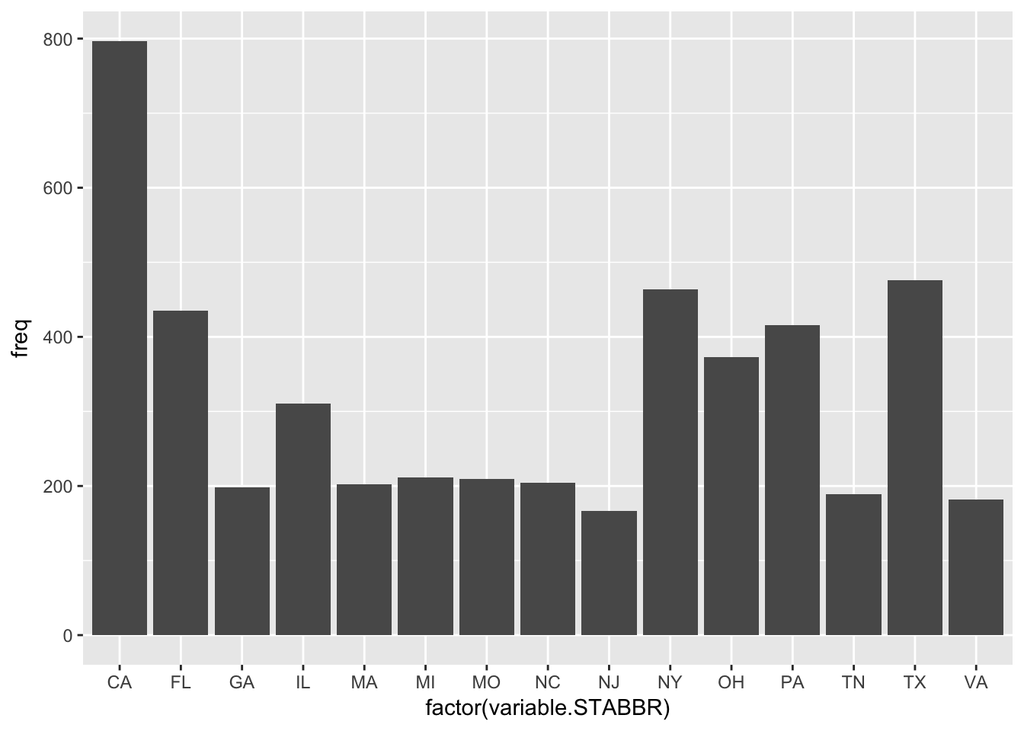

```r
state_freq[1:15,] %>% ggplot(aes(x=factor(variable.STABBR), y=freq)) +
  geom_bar(stat = 'identity')
```

#### 5.1.1.2. Predominant Degree

```r
prop.table(table(data_clean$`variable$preF`)) * 100
```

```
##
##      NotClassified Certificate-degree Associate's-degree
##           5.235468          43.256769          19.953805
##  Bachelor's-degree    Graduate-degree
##          27.319389           4.234569
```

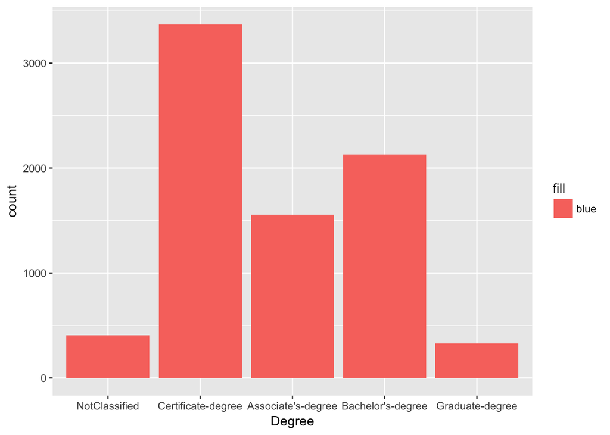

```r
data_clean %>% ggplot(aes(x=variable$`preF`, fill = 'blue')) +
  geom_histogram(stat = "count") +
  xlab("Degree")
```

#### 5.1.1.3. Control of Institution

In addition to State and predominant degree, control of institution is another categorical variable in the dataset. The label of Control is to indicate whether or not a institution is institution is privately owned and whether or not it is a for-profit organization. There are three levels of this variable: Public, Private Nonprofit, and Private-profit. Public school is assumed to be non-profit so it was not further divided into two subgroups. Below we show the percentage summary of each category and a bar char is plotted to facilitate understanding. About 50% out of all institution are private for-profit university, which is the *most dominant type*. Public and Private Nonprofit are pretty tie in terms of number of observation in each category.

```r
prop.table(table(data_clean$`variable$ctrF`)) * 100
```

```
##
##             Public  Private Nonprofit Private For-profit
##           26.53664           25.11228           48.35108
```

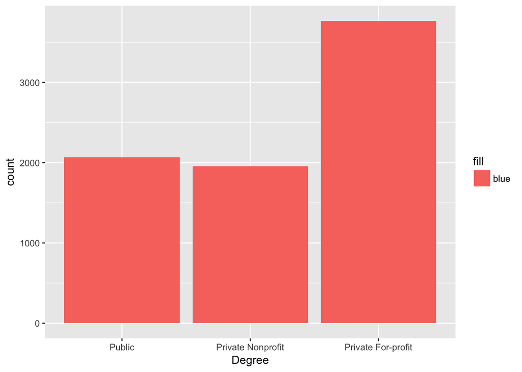

```r
data_clean %>% ggplot(aes(x=variable$`ctrF`, fill = 'blue')) +
  geom_histogram(stat = "count") +
  xlab("Degree")
```

### 5.1.2 Student Body

#### 5.1.2.1 Percentage first-generation students

This element identifies the share of federally aided students at the institution who report that they are first generaion on the FAFSA (Free Application for Federal Student Aid). First generation students are defined as sudents in which neither parents completed college.

We are using the code below to summarize this variable.

```r
summarize(data_clean,
          minPAR_ED_PCT_1STGEN=min(PAR_ED_PCT_1STGEN*100 ,na.rm=TRUE),
          maxPAR_ED_PCT_1STGEN=max(PAR_ED_PCT_1STGEN*100,na.rm=TRUE),
          meanPAR_ED_PCT_1STGEN=mean(PAR_ED_PCT_1STGEN*100,na.rm=TRUE),
          medianPAR_ED_PCT_1STGEN=median(PAR_ED_PCT_1STGEN*100,na.rm=TRUE),
          sdPAR_ED_PCT_1STGEN = sd(PAR_ED_PCT_1STGEN*100,na.rm=TRUE))
```

```
##   minPAR_ED_PCT_1STGEN maxPAR_ED_PCT_1STGEN meanPAR_ED_PCT_1STGEN
## 1             6.872038             95.24941              48.07879
##   medianPAR_ED_PCT_1STGEN sdPAR_ED_PCT_1STGEN
## 1                50.76923            12.16505
```

From the output, we can tell that the highest value is 95.25% while the lowest value is 6.87%. From the mean value of 48.08%, we can tell that about for federally aided students in most colleges, around half (50.8%) of the students’ parents did not complete the college. The standard deviation value of 12.2% indicated a relative high difference of this element among different colleges.

Below is the code to generate a visual representation in the histgram.

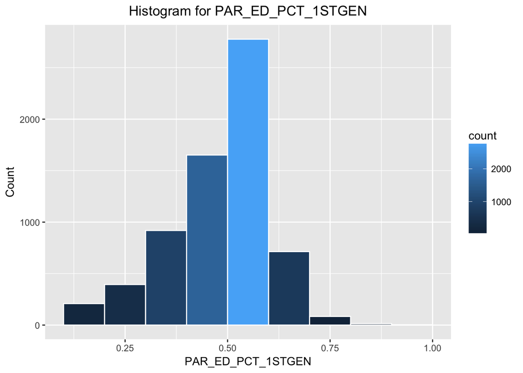

```r
  ggplot(data=data_clean , aes(PAR_ED_PCT_1STGEN)) +
    geom_histogram(breaks=seq(0.1, 1, by =0.1),
                   col="white",
                   aes(fill=..count..),na.rm=TRUE)+
    labs(title="Histogram for PAR_ED_PCT_1STGEN") +
    labs(x="PAR_ED_PCT_1STGEN", y="Count") +
    theme(plot.title = element_text(hjust = 0.5))
```

#### 5.1.2.2 Number of applications

The variable APPL_SCH_PCT_GE2 is to describe the percentage of students who list two and more than two institutions when he apply for financial aid when apply for universities. This information is only available to students who submit their applications for federal aid, and not cover the whole student body. Nevertheless, this variable still can provides some useful insights about how many universities a student usually apply to.

The summry statistics show that median percentage of student submitting two or more than two application is 41.67 across all univerisities. The institution having the least percentage only has 4% of student applying to more than one university, while the school with the highest percent has as high as 90% of student applying to more than one university. The boxplot compare the the percent of student applying to only one university and that of student applying to more than 1. We can clearly see that a larger portion of students only list one instituiton when submitting their application for financial aid.

```r
college_app_2_clean = data_clean$APPL_SCH_PCT_GE2[!is.na(data_clean$APPL_SCH_PCT_GE2)]*100
summary(college_app_2_clean)
```

```
##    Min. 1st Qu.  Median    Mean 3rd Qu.    Max.
##   4.591  33.940  41.670  43.840  51.750  90.830
```

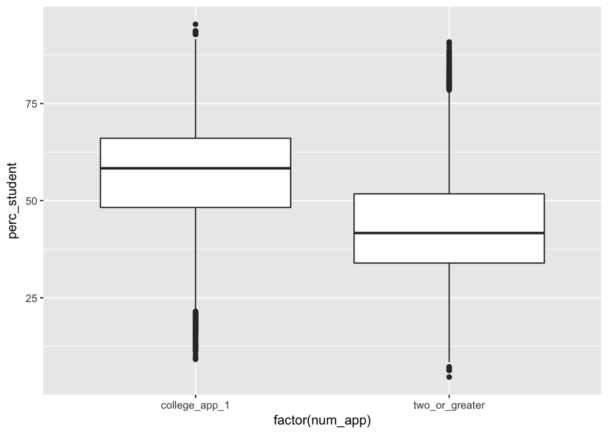

```r
college_app_2_clean %>% as.data.frame() %>%
    mutate(college_app_1 = 100-college_app_2_clean)%>%
    {.}  -> college_app
colnames(college_app)[1] <- "two_or_greater"

college_app %>% gather(key = num_app, value = perc_student) %>%
{.} -> college_app

college_app %>%
    ggplot(aes(factor(num_app), perc_student)) +
    geom_boxplot()
```

### 5.1.3 Cost

#### 5.1.3.1 Average net price for Title IV institutions(both public and private institutions)

We are using the code below to summarize the variable.

```r
summarize(data_clean,
          minNPT4_COMBINE=min(NPT4_COMBINE ,na.rm=TRUE),
          maxNPT4_COMBINE=max(NPT4_COMBINE,na.rm=TRUE),
          meanNPT4_COMBINE=mean(NPT4_COMBINE,na.rm=TRUE),
          medianNPT4_COMBINE=median(NPT4_COMBINE,na.rm=TRUE),
          sdNPT4_COMBINE = sd(NPT4_COMBINE,na.rm=TRUE))
```

```
##   minNPT4_COMBINE maxNPT4_COMBINE meanNPT4_COMBINE medianNPT4_COMBINE
## 1          -19360           87414         15263.24            14962.5
##   sdNPT4_COMBINE
## 1       7604.884
```

From the summary results, we learned that the maximum value of the variable is $87,414 while the minimum value is about $-19,360. Considering the elements are collected from Title IV institutions, we reasoned that the negative values may be due to the fact that some intituions’s finainal aid supoort can cover the students’ all the costs, meanwhile overbalancing the cost amount. There are not much differerences between mean value and median value, which is around $15,000. We can conclude that the average net price costs for most institutuins are falling into the this range. The standard deviation value is 7604.884 which is relatively large, indicating a great spread in the data.

Below is the histogram for this variable which is able to provide us with a visual distrubution presentation.

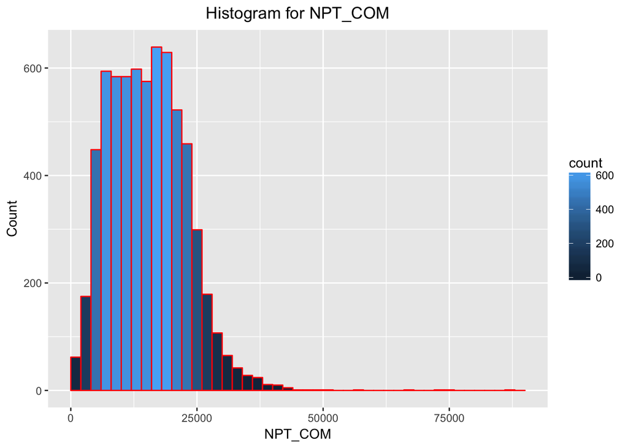

```r
  #histogram for NPT_COM
  ggplot(data=data_clean , aes(NPT4_COMBINE)) +
    geom_histogram(breaks=seq(0, 90000, by =2000),
                   col="red",
                   aes(fill=..count..),na.rm=TRUE)+
    labs(title="Histogram for NPT_COM") +
    labs(x="NPT_COM", y="Count") +
    theme(plot.title = element_text(hjust = 0.5))
```

From the histogram, we notice that the average net cost for IV institutions typically is 16000 -18000. The values between 16000 - 20000 are quite frequent. There were an unsually lagrge number of costs. The institutions with cost of more than 50000 were atypical. Due to the atypical large value, the histogram is abviously right skewed. Without those extreme values, the histogram would be reasonably symmetric.

#### 5.1.3.2 Percentage of students who are financially independent

Here is the code to generate the summary statistics:

```r
summarize(data_clean,
          minDEP_STAT_PCT_IND=min(DEP_STAT_PCT_IND*100 ,na.rm=TRUE),
          maxDEP_STAT_PCT_IND=max(DEP_STAT_PCT_IND*100,na.rm=TRUE),
          meanDEP_STAT_PCT_IND=mean(DEP_STAT_PCT_IND*100,na.rm=TRUE),
          medianDEP_STAT_PCT_IND=median(DEP_STAT_PCT_IND*100,na.rm=TRUE),
          sdDEP_STAT_PCT_IND = sd(DEP_STAT_PCT_IND*100,na.rm=TRUE))
```

```
##   minDEP_STAT_PCT_IND maxDEP_STAT_PCT_IND meanDEP_STAT_PCT_IND
## 1           0.7262823            98.56386             55.92664
##   medianDEP_STAT_PCT_IND sdDEP_STAT_PCT_IND
## 1               61.12138            23.3077
```

From the summary results, we learned that the maximum value of the variable is 98.56% while the minimum value is about 0，73%. From the mean value, we can tell that about in most colleges, around 56% of the students are financially independent. The standatd deviation value of 23.3% indicates a relative high different among different colleges, which can also be concluded from the difference between maximum value and minimum value. Below is the code to generate a visual representation in the histgram.

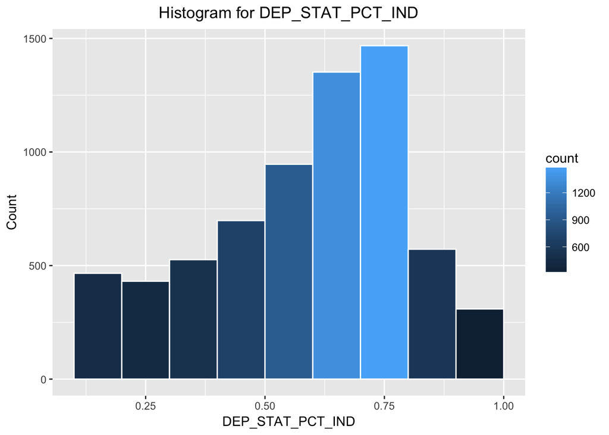

```r
  #histogram for NPT_COM
  ggplot(data=data_clean , aes(DEP_STAT_PCT_IND)) +
    geom_histogram(breaks=seq(0.1, 1, by =0.1),
                   col="white",
                   aes(fill=..count..),na.rm=TRUE)+
    labs(title="Histogram for DEP_STAT_PCT_IND") +
    labs(x="DEP_STAT_PCT_IND", y="Count") +
    theme(plot.title = element_text(hjust = 0.5))
```

Then we grouped by the data into the control type(Private For-profit, Public, Private Nonprofit) to take a further analysis.

```r
data_clean %>%
  group_by(variable$ctrF) %>%
    summarise(minDEP_STAT_PCT_IND=min(DEP_STAT_PCT_IND ,na.rm=TRUE),
    maxDEP_STAT_PCT_IND=max(DEP_STAT_PCT_IND,na.rm=TRUE),medianDEP_STAT_PCT_IND=median(DEP_STAT_PCT_IND,na.rm=TRUE))  %>%
       arrange(desc(medianDEP_STAT_PCT_IND))   %>%
{.}  ->DEP_STAT_PCT_IND_CONTROL

DEP_STAT_PCT_IND_CONTROL
```

[output not shown]

### 5.1.4 Financial Aid

#### 5.1.4.1 Percentage of undergraduates who receive a Pell Grant

This elemnt, pulled from the IPEDS student Financial Aid Component, shows the share of undergraduate students who received Pell Grants in a given year, which is an important measure of the access an insiitution provides to low-income students. We are using the code below to summarize this variable.

```r
summarize(data_clean,
          minPCTPELL=min(PCTPELL*100 ,na.rm=TRUE),
          maxPCTPELL=max(PCTPELL*100,na.rm=TRUE),
          meanPCTPELL=mean(PCTPELL*100,na.rm=TRUE),
          medianPCTPELL=median(PCTPELL*100,na.rm=TRUE),
          sdPCTPELL = sd(PCTPELL*100,na.rm=TRUE))
```

```
##   minPCTPELL maxPCTPELL meanPCTPELL medianPCTPELL sdPCTPELL
## 1          0        100    53.29103         52.66  22.56898
```

From the output, we can tell that the range is between 0 to 100%. Among the colleges in the sample, half colleges have this rate as high as 52.7% (median value of 52.7%), which means more than half of undergraduare students are able to receive the Pell Grant to cover their costs. The standard deviation value is 22.57%, indicating a relative high difference of this element among different colleges, which can also be noticed from the largest range (100%). Below is the code to generate a visual representation in the histgram.

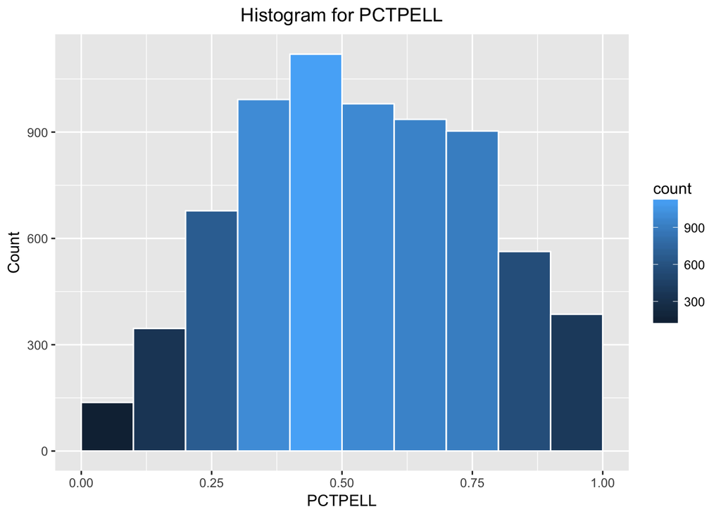

```r
  ggplot(data=data_clean , aes(PCTPELL)) +
    geom_histogram(breaks=seq(0, 1, by =0.1),
                   col="white",
                   aes(fill=..count..),na.rm=TRUE)+
    labs(title="Histogram for PCTPELL") +
    labs(x="PCTPELL", y="Count") +
    theme(plot.title = element_text(hjust = 0.5))
```

#### 5.1.4.2 Percent of all federal undergraduate students receiving a federal student loan

This elemnt, as reported in the IPEDs Student Finaicial Aid component, show the share of undergraduate students who received federal loans in a given year. It can provide important context to figures related to debt, repayment and non-repayment.  
We are using the code below to summarize this variable.

```r
summarize(data_clean,
          minPCTFLOAN=min(PCTFLOAN*100 ,na.rm=TRUE),
          maxPCTFLOAN=max(PCTFLOAN*100,na.rm=TRUE),
          meanPCTFLOAN=mean(PCTFLOAN*100,na.rm=TRUE),
          medianPCTFLOAN=median(PCTFLOAN*100,na.rm=TRUE),
          sdPCTFLOAN = sd(PCTFLOAN*100,na.rm=TRUE))
```

```
##   minPCTFLOAN maxPCTFLOAN meanPCTFLOAN medianPCTFLOAN sdPCTFLOAN
## 1           0         100     53.64715          60.08   29.26151
```

From the output, we can tell that the range is between 0 to 100%. Among the colleges in the sample, half colleges have this rate as high as 60.08% , which means around 60% of undergraduare students are able to receive the fedaral student loans. The standard deviation value is 29.26%, indicating a relative high difference of this element among different colleges, which can also be noticed from the largest range (100%). Below is the code to generate a visual representation in the histgram.

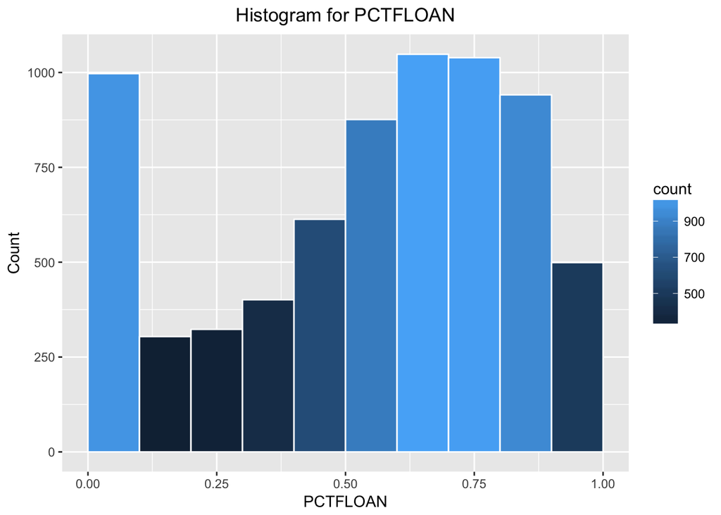

```r
  ggplot(data=data_clean , aes(PCTFLOAN)) +
    geom_histogram(breaks=seq(0, 1, by =0.1),
                   col="white",
                   aes(fill=..count..),na.rm=TRUE)+
    labs(title="Histogram for PCTFLOAN") +
    labs(x="PCTFLOAN", y="Count") +
    theme(plot.title = element_text(hjust = 0.5))
```

From the histogram, it’s obvious that there are two peaks in the graph. The rates between 0- 10% and the rates between 60% to 80% are similarly frequent compated to the other ranges.

```r
data_clean %>%
  group_by(variable$STABBR ) %>%
    dplyr::summarise(minPCTFLOAN=min(PCTFLOAN ,na.rm=TRUE),
    maxPCTFLOAN=max(PCTFLOAN,na.rm=TRUE),medianPCTFLOAN=median(PCTFLOAN,na.rm=TRUE))  %>%
       arrange(medianPCTFLOAN)   %>%
{.}  ->PCTFLOAN_STATE

PCTFLOAN_STATE
```

```
## # A tibble: 59 × 4
##    `variable$STABBR` minPCTFLOAN maxPCTFLOAN medianPCTFLOAN
##               <fctr>       <dbl>       <dbl>          <dbl>
## 1                 AS      0.0000      0.0000        0.00000
## 2                 FM      0.0000      0.0000        0.00000
## 3                 GU      0.0000      0.3564        0.00000
## 4                 MH      0.0000      0.0000        0.00000
## 5                 MP      0.0000      0.0000        0.00000
## 6                 PR      0.0000      0.6618        0.00000
## 7                 PW      0.0000      0.0000        0.00000
## 8                 AK      0.0000      0.7961        0.25540
## 9                 WY      0.1036      0.9722        0.27915
## 10                VI      0.3105      0.3105        0.31050
## # ... with 49 more rows
```

```r
data_clean %>%
  group_by(variable$ctrF ) %>%
    dplyr::summarise(minPCTFLOAN=min(PCTFLOAN ,na.rm=TRUE),
    maxPCTFLOAN=max(PCTFLOAN,na.rm=TRUE),medianPCTFLOAN=median(PCTFLOAN,na.rm=TRUE))  %>%
       arrange(medianPCTFLOAN)   %>%
{.}  ->PCTFLOAN_CONTROL

PCTFLOAN_CONTROL
```

```
## # A tibble: 3 × 4
##      `variable$ctrF` minPCTFLOAN maxPCTFLOAN medianPCTFLOAN
##               <fctr>       <dbl>       <dbl>          <dbl>
## 1             Public           0           1         0.3213
## 2  Private Nonprofit           0           1         0.6471
## 3 Private For-profit           0           1         0.6875
```

[figure not shown]

```r
#stacked histogram
data_clean %>%
  ggplot(aes(x=PCTFLOAN)) +
  geom_bar(binwidth=5,aes(fill=variable$ctrF ))
```

From the result, the Private institutions have a much larger value than the public institutions. With a much higher costs burden, it makes sence that the low-income sutdents in private institutions are much more likely to seek financial aid than the public institution students.

#### 5.1.4.3 The median debt for students who have completed

This element is the median loan debt acculated at the institution by all student borrowers of federal lonans who have habe completed the education.We are using the code below to summarize this variable.

```r
summarize(data_clean,
          minGRAD_DEBT_MDN=min(GRAD_DEBT_MDN ,na.rm=TRUE),
          maxGRAD_DEBT_MDN=max(GRAD_DEBT_MDN,na.rm=TRUE),
          meanGRAD_DEBT_MDN=mean(GRAD_DEBT_MDN,na.rm=TRUE),
          medianGRAD_DEBT_MDN=median(GRAD_DEBT_MDN,na.rm=TRUE),
          sdGRAD_DEBT_MDN = sd(GRAD_DEBT_MDN,na.rm=TRUE))
```

```
##   minGRAD_DEBT_MDN maxGRAD_DEBT_MDN meanGRAD_DEBT_MDN medianGRAD_DEBT_MDN
## 1             1448            48250           15819.5               14000
##   sdGRAD_DEBT_MDN
## 1        8020.958
```

From the output, we can tell that the highest value is 48,250 while the lowest value is 1448. From the median value of 14000, we can tell that among the colleges in the sample, the students who have completed the deducaiton from half of them had the median loan debt of 14000. The standard deviation value is 8020.958, indicating a relative high difference of this element among different colleges. Below is the code to generate a visual representation in the histgram.

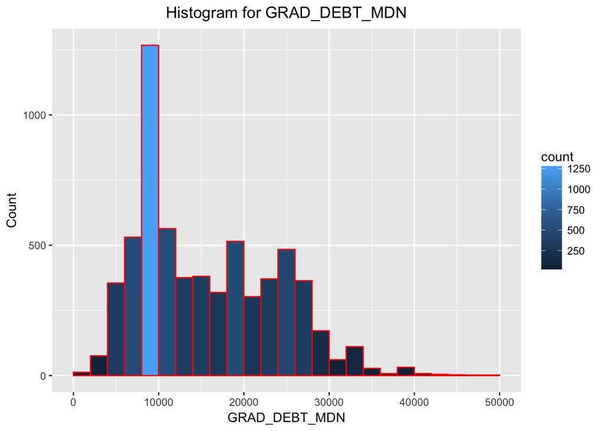

```r
 ggplot(data=data_clean , aes(GRAD_DEBT_MDN)) +
    geom_histogram(breaks=seq(0, 50000, by =2000),
                   col="red",
                   aes(fill=..count..),na.rm=TRUE)+
    labs(title="Histogram for GRAD_DEBT_MDN") +
    labs(x="GRAD_DEBT_MDN", y="Count") +
    theme(plot.title = element_text(hjust = 0.5))
```

#### 5.1.4.4 The median debt for students who have not completed

WDRAW_DEBT_MDN describe the median number of debt fot students who ahve not completed their study. In other words, they are still attending the university. The summary statistics show that student in 50% of institution have a median debt of 5500.The median debt for attending students can be as much as 27620 for some school and as low as 600 for other. So we also calculate standard deviation to measure the dispenser of the distribution. The standard deviation is 2415.623 about 95% of institution have a median debt ranging from 1167.754 to 10830.246. The histogram that the distribution of the median roughly follows a standard distribution with a sharp peak and slightly heavy tail.

```r
median_debt_non_null = data_clean$WDRAW_DEBT_MDN[!is.na(data_clean$WDRAW_DEBT_MDN)]
summary(median_debt_non_null)
```

```
##    Min. 1st Qu.  Median    Mean 3rd Qu.    Max.
##     603    4613    5500    5999    7163   27620
```

```r
sd(median_debt_non_null)
```

```
## [1] 2415.623
```

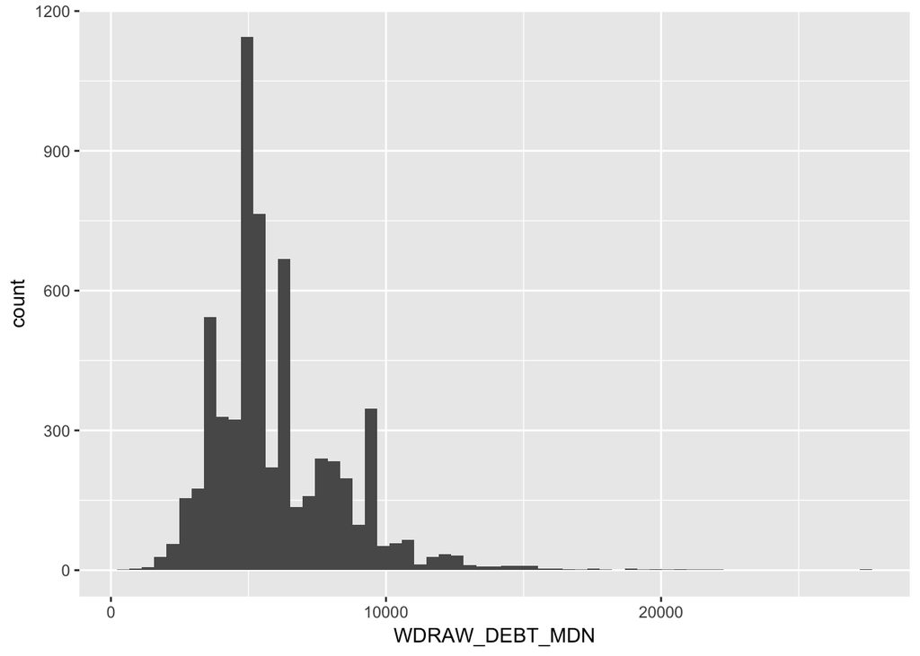

```r
#plot a ggplot to better illustrate
data_clean %>% ggplot(aes(x = WDRAW_DEBT_MDN)) +
                geom_histogram(binwidth = 450) #warning?
```

[figure not shown]

```r
ggplot(data=data_clean,
       aes(x=WDRAW_DEBT_MDN,
           fill = I('red'))) +
    geom_density(alpha=0.5) +
    scale_x_continuous("Median Debt for Students Who Have Completed")
```

### 5.1.5 Earning

#### 5.1.5.1 Median family income in real 2015 dollars

This elemnt is recording the median family income of students, one of the undergraduate student demographics for earnings cohorts.

We are using the code below to summarize this variable.

```r
summarize(data_clean,
          minMD_FAMINC=min(MD_FAMINC ,na.rm=TRUE),
          maxMD_FAMINC=max(MD_FAMINC,na.rm=TRUE),
          meanMD_FAMINC=mean(MD_FAMINC,na.rm=TRUE),
          medianMD_FAMINC=median(MD_FAMINC,na.rm=TRUE),
          sdMD_FAMINC = sd(MD_FAMINC,na.rm=TRUE))
```

```
##   minMD_FAMINC maxMD_FAMINC meanMD_FAMINC medianMD_FAMINC sdMD_FAMINC
## 1            0     155606.6      25963.84        19262.26    18824.31
```

From the output, we can tell that the highest value is 155,606.6 while the lowest value is 0. From the median value of 19,262.26, we can tell that among the colleges in the sample, the students in half of them had the family income below 19,262.26 . The standard deviation value is 18,824.31, indicating a relative high difference of this element among different colleges. Below is the code to generate a visual representation in the histgram.

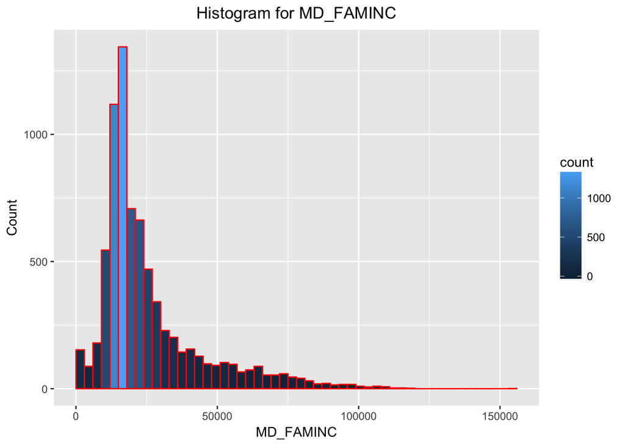

```r
  ggplot(data=data_clean , aes(MD_FAMINC)) +
    geom_histogram(breaks=seq(0, 156000, by =3000),
                   col="red",
                   aes(fill=..count..),na.rm=TRUE)+
    labs(title="Histogram for MD_FAMINC") +
    labs(x="MD_FAMINC", y="Count") +
    theme(plot.title = element_text(hjust = 0.5))
```

#### 5.1.5.2 Earning after graduation

```r
earning = select(data_clean, MD_EARN_WNE_P6, MD_EARN_WNE_P10 )
earning_clean = na.omit(earning)
earning_clean %>%
    mutate(salary_increase = MD_EARN_WNE_P10-MD_EARN_WNE_P6) %>%
    {.} -> earning_clean
summary(earning_clean)
```

```
##  MD_EARN_WNE_P6   MD_EARN_WNE_P10  salary_increase
##  Min.   :  8300   Min.   :  9500   Min.   :-34600
##  1st Qu.: 20100   1st Qu.: 23900   1st Qu.:  3000
##  Median : 25300   Median : 30800   Median :  5500
##  Mean   : 26885   Mean   : 33012   Mean   :  6127
##  3rd Qu.: 31625   3rd Qu.: 39000   3rd Qu.:  8500
##  Max.   :120200   Max.   :233100   Max.   :155900
```

```r
apply(earning_clean, 2, sd) #dispersion increases
```

```
##  MD_EARN_WNE_P6 MD_EARN_WNE_P10 salary_increase
##       10245.826       14249.719        6540.578
```

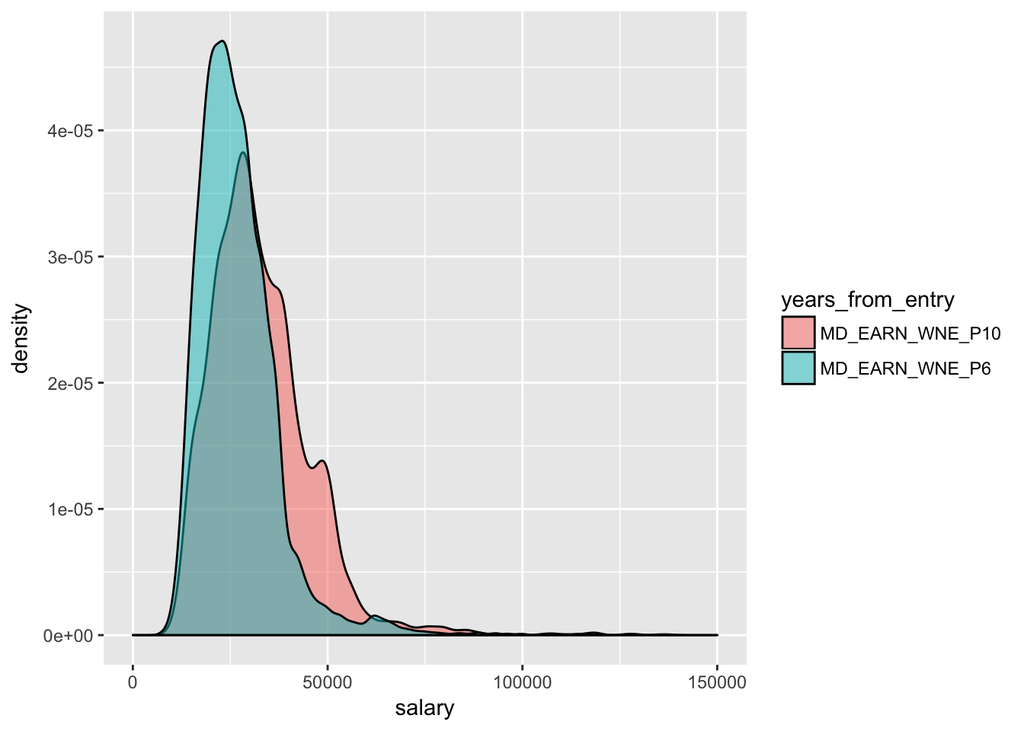

```r
earning_clean %>% gather(key = years_from_entry, value = salary) %>%
    {.} -> earning_clean1

earning_clean1[earning_clean1$years_from_entry != 'salary_increase',] %>%
    ggplot(aes(x = salary, fill =years_from_entry )) +
    geom_density(alpha = 0.5) +
    xlim(0, 150000)
```

### 5.1.6 Repayment

#### 5.1.6.1 3-year Repayment rate

The variable RPY_3YR_RT_SUPP measure the percentage of student who entered repayemtn from October 1, 2010 to September 30, 2011, and made progress in the following three years. Repayment rates are generally considered most sensitive than default rates(we study later), which measure only the worse-case scenario for repayment outcomes. From the summary statistics, we see that 50% institutions have 40% of students who are making progress in their repayment. A histogram is also plotted to show the distribution, clearly with a heavy tail.

```r
repayment_clean = na.omit(data_clean$RPY_3YR_RT_SUPP)
summary(repayment_clean)
```

```
##    Min. 1st Qu.  Median    Mean 3rd Qu.    Max.
## 0.06696 0.26860 0.40880 0.43880 0.58540 0.94350
```

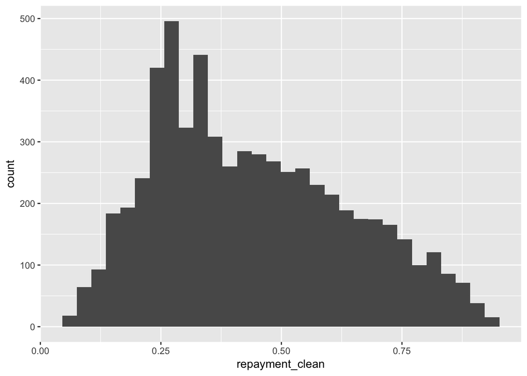

```r
qplot(repayment_clean, geom = "histogram")
```

#### 5.1.6.2 3-year Default rate

The three-year cohort default rate describe the repayment in the opposite of repayment rate. In this dataset, it was calculated using the cohort of borrowers who entered repayment on their federal student loans between Octorber 1, 2010 to September 30, 2011, and who defaulted before September 2012. The median default rate aross all universities is 13%, which means that 50% of universities have 13 out of 100 students defaulted their loan!

```r
default_clean = na.omit(data_clean$CDR3)
summary(default_clean)
```

```
##    Min. 1st Qu.  Median    Mean 3rd Qu.    Max.
##  0.0000  0.0530  0.1310  0.1386  0.2140  1.0000
```

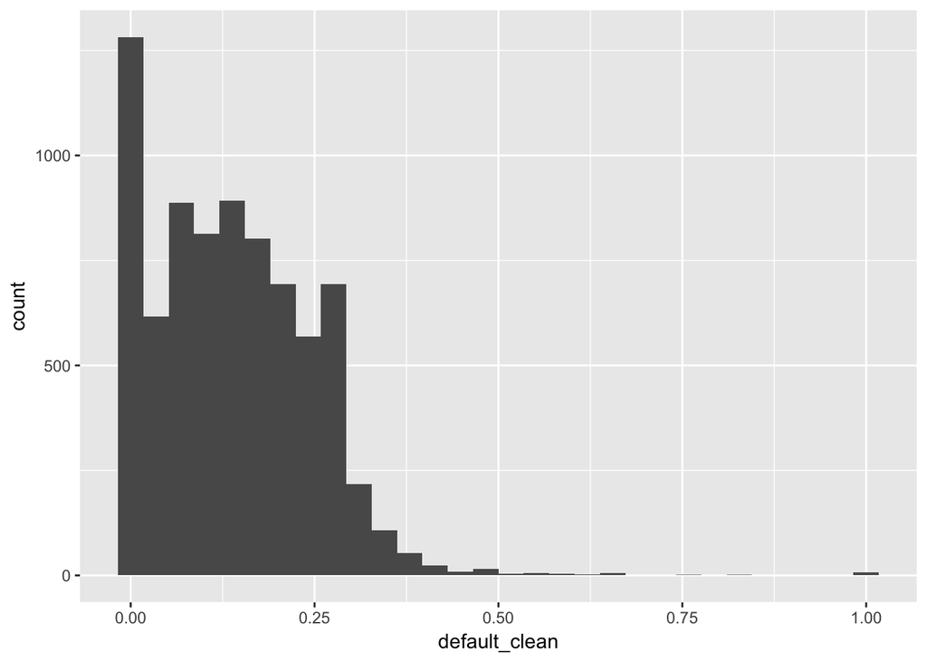

```r
qplot(default_clean, geom = "histogram")
```

```r
summary(data_clean$RPY_3YR_RT_SUPP + data_clean$CDR3)
```

```
##    Min. 1st Qu.  Median    Mean 3rd Qu.    Max.    NA's
##  0.1316  0.4865  0.6007  0.6026  0.7161  0.9656    1738
```

# 6. Relationship between variables

# 6.1 NPT4_COMBINE VS State

To analyze the relationship between average net cost for Title IV institutions and State, we grouped the data into the state level to take a further look.

```r
data_clean %>%
  group_by(variable$STABBR) %>%
    dplyr::summarise(minNPT4_COMBINE=min(NPT4_COMBINE ,na.rm=TRUE),
    maxNPT4_COMBINE=max(NPT4_COMBINE,na.rm=TRUE),medianNPT4_COMBINE=median(NPT4_COMBINE,na.rm=TRUE))  %>%
       arrange(desc(medianNPT4_COMBINE))   %>%
{.}  ->NPT4_STATE

NPT4_STATE
```

```
## # A tibble: 59 × 4
##    `variable$STABBR` minNPT4_COMBINE maxNPT4_COMBINE medianNPT4_COMBINE
##               <fctr>           <dbl>           <dbl>              <dbl>
## 1                 DC            6231           33931            23314.0
## 2                 VT            6695           37755            21501.0
## 3                 MA            4158           74122            19787.0
## 4                 NH            9010           27999            19018.0
## 5                 RI            5708           41575            18815.0
## 6                 DE            4537           29986            18434.0
## 7                 VA            1807           39337            18006.0
## 8                 CO            4959           39920            17745.0
## 9                 AZ            2986           41891            17450.5
## 10                IN            -342           32700            17301.5
## # ... with 49 more rows
```

Baesd on the output, we can see the highest median value for avreage net price exists in DC while the lowest median value is in AS(American Samoa).Moreover, we found that the top 5 states are DC, VT, MA, NH, RI, which are all states conceiving amount of well-known educational institutions.

# 6.2 Debt VS Cost

We assume there would be a strong linear relationship between the average net price for Title IV institutions and the median debt for students who have completed. We hypothese that the students who completed education in colleges with high costs will have a highe value of median debt. We use the following code to generate the scatterplot between these two variables to verify our assumptions.

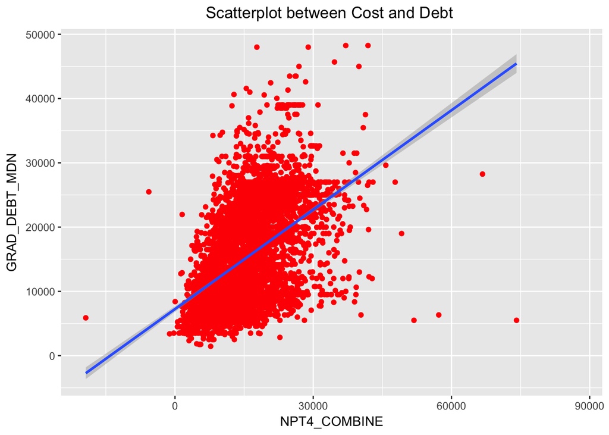

```r
ggplot(data_clean, aes(x =NPT4_COMBINE, y = GRAD_DEBT_MDN)) + geom_point(color="red")+  geom_smooth(method = "lm", se = TRUE)+
  labs(title="Scatterplot between Cost and Debt ") +
    theme(plot.title = element_text(hjust = 0.5))
```

From the scatter plot, it is obvious that the NPT4_COMBINE is in positive linear relationship with GRAD_DEBT_MDN: the data show an uphill pattern from left to right; As the average net price for Title IV institutions increase, the value of median debt for students who have completed increases as well.

# 6.3 Percentage of Pell Grant VS college type(CONTROL)

To compare the percentages of Pell Grant in different control type(), we grouped the Percentage of Pell Grant data into the college type level to take a further analysis.

```r
data_clean %>%
  group_by(variable$ctrF ) %>%
    dplyr::summarise(minPCTPELL=min(PCTPELL ,na.rm=TRUE),
    maxPCTPELL=max(PCTPELL,na.rm=TRUE),medianPCTPELL=median(PCTPELL,na.rm=TRUE))  %>%
       arrange(medianPCTPELL)   %>%
{.}  ->PCTPELL_CONTROL

PCTPELL_CONTROL
```

```
## # A tibble: 3 × 4
##      `variable$ctrF` minPCTPELL maxPCTPELL medianPCTPELL
##               <fctr>      <dbl>      <dbl>         <dbl>
## 1  Private Nonprofit          0      1.000       0.40345
## 2             Public          0      0.997       0.41590
## 3 Private For-profit          0      1.000       0.65930
```

From the result, the Private Nonprofit institutions and Public institutions have a similar low median values while the provate For- profit institutions have a hgihest value. This is resonable because generally speanking, the private for-profit colleges may have much higher costs than the private nonprofit and public institutions. The low-income students were more likely to seek a Pell Grant for assistant. Additionally, in some states, state financial aid may be sufficient to cover costs at community colleges; thus the students in thoes schools may not need to seek for addtional financial aid like Pell Grant.

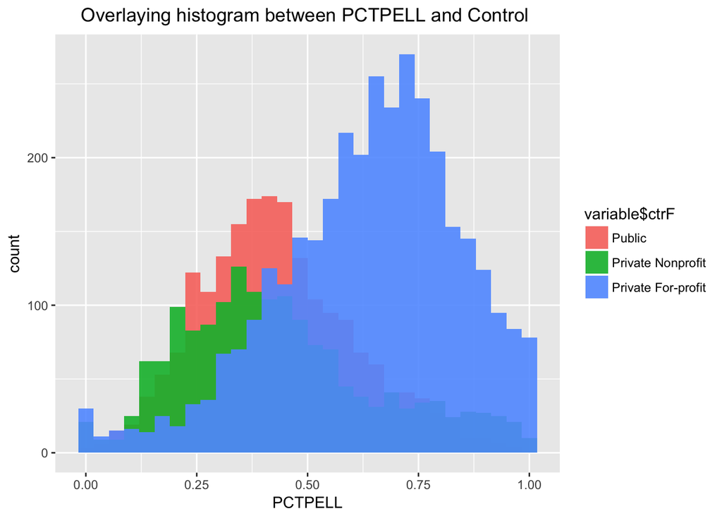

```r
ggplot(data_clean, aes(x=PCTPELL, fill=variable$ctrF)) + geom_histogram(alpha=0.9, position="identity") +
  labs(title="Overlaying histogram between PCTPELL and Control ") +
    theme(plot.title = element_text(hjust = 0.5))
```

From the overlaying histograms, the percentage of students who receive Pell Grant are quite frequent for Private For-profit institutions between 0.7 and 0.75 ; the percentage of students who receive Pell Grant are quite frequent around 0.4 for Public institutions and Private Nonprofit institutions. The histogram for private for profit is slightly left skewed due to atypical small value near 0. The histogram for public and private nonprofit institions are reasonably symmetric

# 6.4 Percentage first-generation students VS Status

To compare the Percentage first-generation students with the different states, we grouped data into the state level to take a further analysis.

```r
data_clean %>%
  group_by(variable$STABBR ) %>%
    dplyr::summarise(minPAR_ED_PCT_1STGEN=min(PAR_ED_PCT_1STGEN ,na.rm=TRUE),
    maxPAR_ED_PCT_1STGEN=max(PAR_ED_PCT_1STGEN,na.rm=TRUE),medianPAR_ED_PCT_1STGEN=median(PAR_ED_PCT_1STGEN,na.rm=TRUE))  %>%
       arrange(medianPAR_ED_PCT_1STGEN)   %>%
{.}  ->PAR_ED_PCT_1STGEN_STATE

PAR_ED_PCT_1STGEN_STATE
```

```
## # A tibble: 59 × 4
##    `variable$STABBR` minPAR_ED_PCT_1STGEN maxPAR_ED_PCT_1STGEN
##               <fctr>                <dbl>                <dbl>
## 1                 ND           0.20152956            0.5073886
## 2                 SD           0.14950635            0.5367384
## 3                 VT           0.13921569            0.5641026
## 4                 MN           0.08557047            0.5519006
## 5                 MT           0.22372881            0.5326087
## 6                 IA           0.12742100            0.5498708
## 7                 NE           0.18613607            0.5672515
## 8                 RI           0.09750567            0.6257862
## 9                 PW           0.41826923            0.4182692
## 10                GU           0.42307692            0.5697013
## # ... with 49 more rows, and 1 more variables:
## #   medianPAR_ED_PCT_1STGEN <dbl>
```

# 6.5 family income with Pell Grant

We assume there would be a strong linear relationship between family income and the percentage of students who can receive the Pell Grant. We hypothese that colleges with small value of family income would tend to have high percentages of Pell Grant. The following codes are used to generate the scatter pkot between these two varaibles.

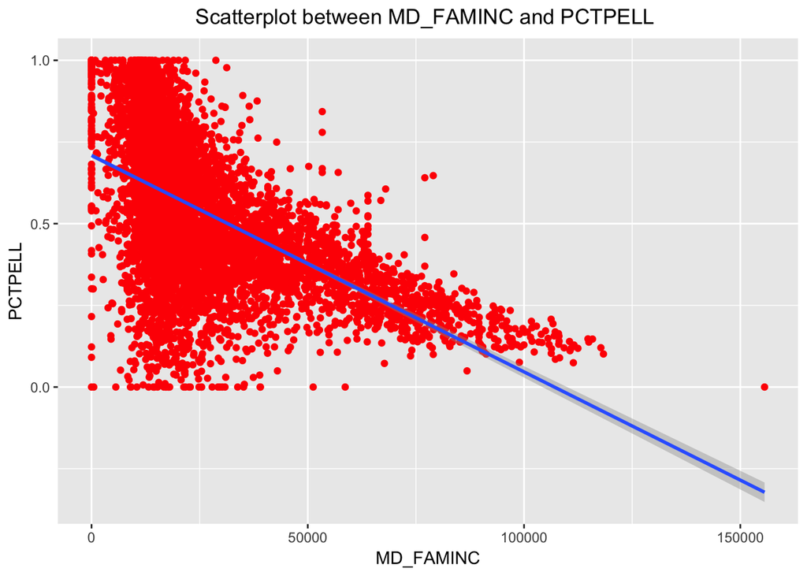

```r
ggplot(data_clean, aes(x =MD_FAMINC, y = PCTPELL)) + geom_point(color="red")+  geom_smooth(method = "lm", se = TRUE)+
  labs(title="Scatterplot between MD_FAMINC and PCTPELL ") +
    theme(plot.title = element_text(hjust = 0.5))
```

From the scatter plot, it is obvious that the MD_FAMINC is in a negative linear relationship with PCTPELL: the data show a downhill pattern from left to right; As the MD_FAMINC increase, the value of PCTPELL decreases.

# 7. Comparison between variables

# 7.1 PCTPELL VS PCTFLOAN

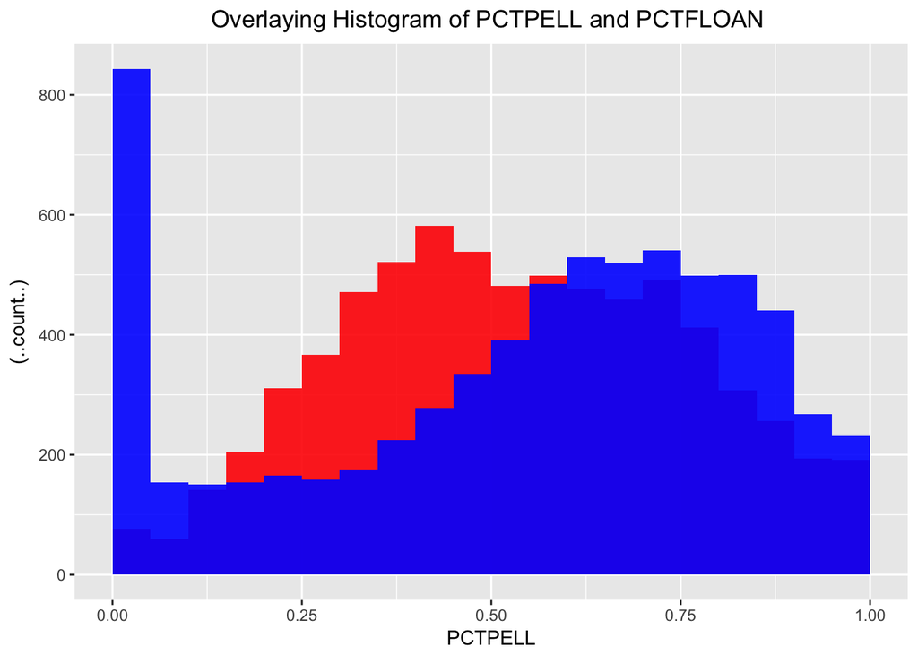

```r
library(ggplot2)
ggplot(data = data_clean) +
  geom_histogram(breaks=seq(0, 1, by =0.05),aes(x = PCTPELL, y=(..count..)),
                       alpha=0.9, fill ="red",position="dodge") +
  geom_histogram(breaks=seq(0, 1, by =0.05),aes(x = PCTFLOAN, y=(..count..)),
                       alpha=0.9,fill ="blue",position="dodge") +
  labs(title="Overlaying Histogram of PCTPELL and PCTFLOAN ") +
    theme(plot.title = element_text(hjust = 0.5)) +
  scale_colour_manual("",
                      breaks = c("PCTPELL", "PCTFLOAN"),
                      values = c("PCTPELL"="red", "PCTFLOAN"="blue"))
```

# 8. Findings and Conclusion